# Linear Algebra

Autumn 2025

## Equations

- Mathematics allows us to model the world using equations.
- E.g.,
  - probability distributions,
  - progression of disease through a population,
  - explosive force over distance,
  - exchange rate of currencies,
  - trajectory of a ball through the air.
- Generally, we can process more information visually than by looking at numbers and symbols.

\[ f(x)=\frac {1}{\sqrt {2\pi \sigma^2}} e^{-{\frac {(x-\mu )^2}{2\sigma^2}}} \]

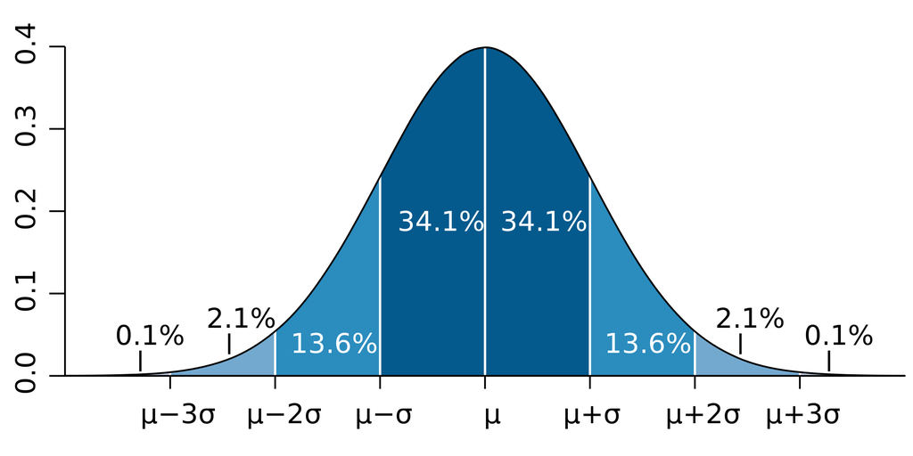

## Linear algebra

- In this session, we will focus on linear equations and vectors,

  a simple but powerful model.
- Models *“flat”* objects (points, lines, planes) in space.
- Useful in, among many others, computer graphics and vision, data analysis, machine learning, quantum physics…
- The more general concept of matrices and vectors can be applied even more widely (to non-flat objects)
- For every linear equation (or system), there is a corresponding picture.
- Granted, sometimes the picture might be in \(42\)-dimensional space…

## Equations

- mathematical *formula* (usually cantaining unknows variables) with an *equality*.
  - \(5x^2 - 3x + 4 = 0\)
  - \(e^{a^2} + \tfrac{1}{a} = 4\)
  - \(3y + 2z = 4w + y\)
  - \(c = 5\)

## Solutions to equations

- A *solution* is a value, which can be assigned to an unknown variable to make the equality true.
  - For example, \(x^2 = 9\)
  - when \(x = 3\), we have \(3^2 = 9\) and \(x = -3\), we have \((-3)^2 = 9\),
  - \(3\) and \(-3\) are solutions to \(x^2 = 9\).
- Sometimes we specify the *number set* for our solutions
  - The equation \(y^2 = 3\) has solutions \(\pm \sqrt{3}\) – two *real* solutions but no *rational* or *integer* solutions.
  - The equation \(z^2 = -1\) has *no real* solutions, but does have solutions over *complex* numbers.

## Linear equations

\[ a_1 x_1 + a_2 x_2 + \cdots + a_n x_n = b \]

- In any number of unknown variables \(x_1,\ldots,x_n\),
- Variables multiplied by a real number (\(a_1,\ldots,a_n, b\)),
- Solutions in *real numbers*.
- no fractions, powers or special functions (e.g., \(\sin\), \(\log\))
- For example
  - \(x + 1 = 3\)
  - \(2x + 3y = 4\)
  - \(\frac{1}{4} x_1 + \frac{13}{19}x_2 + \frac{12}{19} x_3 = \frac{pi}{2}\)

## Systems of linear equations

\[ \begin{align*} a_{11}x_{1}+a_{12}x_{2}+a_{13}x_{3}+\cdots a_{1n}x_{n}=&b_{1}\\a_{21}x_{1}+a_{22}x_{2}+a_{23}x_{3}+\cdots a_{2n}x_{n}=&b_{2}\\\vdots&\\a_{m1}x_{1}+a_{m2}x_{2}+a_{m3}x_{3}+\cdots a_{mn}x_{n}=&b_{m} \end{align*} \]

- A related collection of one or more (\(m\) here) equations in one or more (\(n\) here) unknowns.
- A solution \(x_1=c_1, x_2=c_2,\ldots,x_n=c_n\) is an assignment of real numbers to variables which makes *all* equations true.

## Two equations in two unknowns

\[ \begin{align*} 3x_{1}+5x_{2}=&9\\x_{1}-x_{2}=&1 \end{align*} \]

Flashbacks to algebra in school…

## Two equations in two unknowns

\[ \begin{align*} 3x_{1}+5x_{2}=&9\\x_{1}-x_{2}=&1 \end{align*} \]

One might prefer to draw a picture…

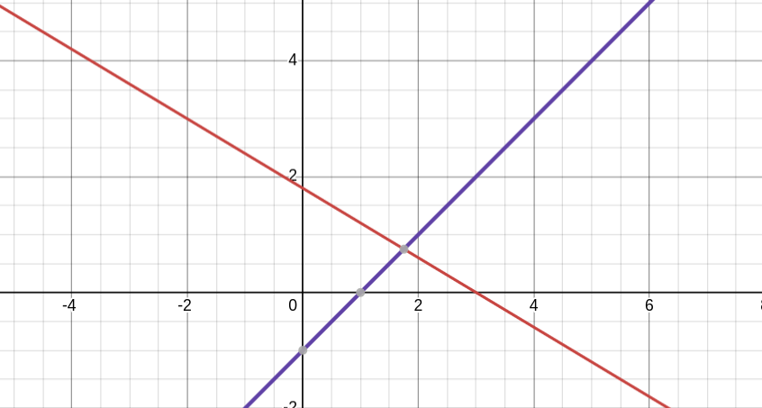

- Each straight line represents one equation
- The intersection point is the solution to the system.

## Possibilities

\[ \begin{align*} a_1 x_1 + b_1 x_2 &= c_1\\ a_2 x_1 + b_2 x_2 &= c_2\\ \end{align*} \]

1. Unique solutions: lines intersect in a unique point,
2. No solutions: lines are parallel and never intersect,
3. Infinite solutions: equations represent the same straight line.

This generalises to any number of equations in any number of unknowns.

## Lines, planes and equations

1. How many *points* is needed to define a straight line?
2. How many *equations* is needed to define a straight line in 2D?
3. How many points is needed to define a plane?
4. How many *equations* is needed to define a plane in 2D?
5. How many *equations* is needed to define a straight line in 3D?

## Vectors

- A vector is a *half-line*, *arrow*, or *ray*,
- Can be thought of as an infitily, infinitely thin line, like a light ray.
- Starts at the *origin* \((0,0,\ldots,0)\)
- Defined by its *magnitude* (how long the arrow is),
- and *direction* (angle the line makes with a fixed, usually horizontal axis).
- Vectors work in any dimension.

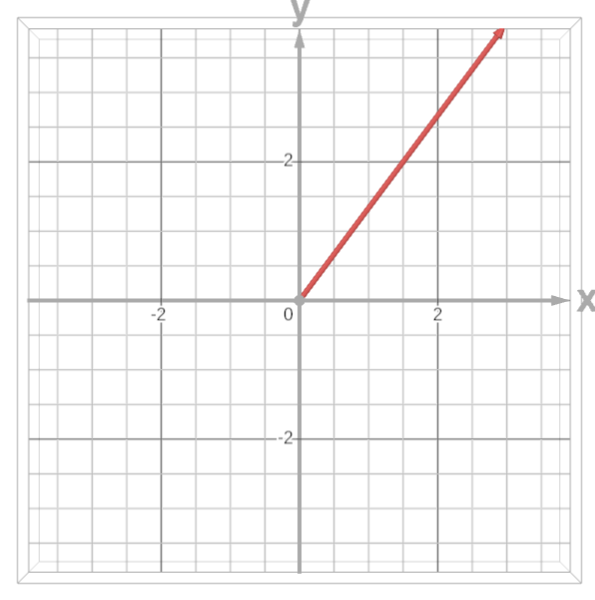

## Representations

- Depending on how we want to use them, we can represent vectors in many different ways.
- **Cartesian Co-ordinates**: an ordered tuple \((x_1,x_2,\ldots,x_n)\) representing the co-ordinate values
- **Polar Co-ordinates**: \((r, \theta)\), where \(r\) is the length and \(\theta\) is the anticlockwise angle with the \(x\)-axis.
- **Using a basis**: \(x \mathbf{i} + y \mathbf{j}\), where \(\mathbf{i}\) and \(\mathbf{j}\) are unit vectors pointing along the \(x\)- and \(y\)-axex.

## Cartesian

The one we all know and love from primary school.

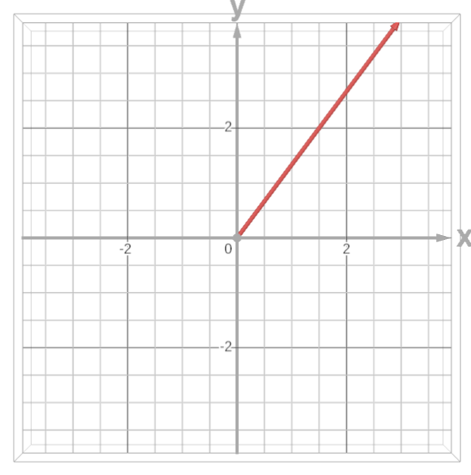

\((3, 4)\) – three along, four up.

## Adding Vectors

To add vectors \(\mathbf{u} = \pmatrix{u_1 \\ u_2\\} = \pmatrix{3 \\ 4}\) and \(\mathbf{v} = \pmatrix{v_1 \\ v_2} = \pmatrix{2 \\ -1}\),

We add their components \[ \mathbf{u} + \mathbf{v} = \begin{pmatrix}3+2\\ 4+-1 \end{pmatrix}=\begin{pmatrix}5\\ 3 \end{pmatrix} \]

## Adding vectors

To graphically add \(\mathbf{u}\) and \(\mathbf{v}\)…

Attach the tail of \(\mathbf{v}\) to the head of \(\mathbf{u}\), the head of \(\mathbf{v}\) points to \(\mathbf{u} + \mathbf{v}\).

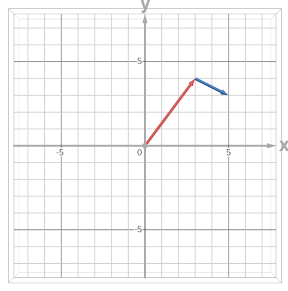

## Scaling vectors

Multiply a vector \(\mathbf{v} = \begin{pmatrix}3 \\ 4\end{pmatrix}\) by a number \(m = 3/2\).

Multiply each component of \(\mathbf{u}\) by \(m\): \[ m\cdot\mathbf{u}=\frac{3}{2}\begin{pmatrix}3\\ 4 \end{pmatrix}=\begin{pmatrix}9/2\\ 6 \end{pmatrix} \]

## Distance

How far apart are \(\mathbf{u} = \begin{pmatrix}3 \\ 4\end{pmatrix}\) and \(\mathbf{v} = \begin{pmatrix}2 \\ -1\end{pmatrix}\)

We need to find the *distance* between \((3,4)\) and \((2, -1)\).

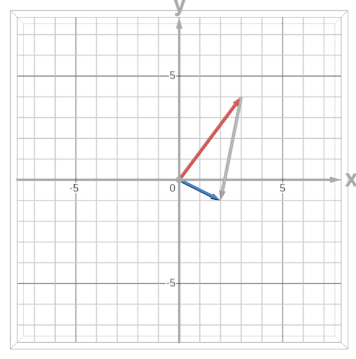

We know that \(3\) and \(2\) are *one square* apart, and \(4\) and \(-1\) are *five squares* apart.

Now we can use *Pythagoras’ Theorem* to find the distance: \[ d^2 = 1^2 + 5^2 = 26 \Longrightarrow d = \sqrt{26}. \]

- It turns out that Pythagoras’ theorem works in higher dimensions…
- I.e., if we have two vectors \(\mathbf{u} = (u_1,\ldots,u_n)\) and \(\mathbf{v} = (v_1,\ldots,v_n)\),
- Then we calculate their distance as

  \(\sqrt{ (v_1 - u_1)^2 + (v_2 - u_2)^2 + \cdots + (v^n - u^n)^2 }\)
- See also [https://youtu.be/mceaM2_zQd8]

## Quick note

- Take care that the vectors you are adding / multiplying / finding the distance / computing the dot product are *compatible*.
- I.e., these operations only work if vectors have the *same number of components*.

## What’s the point, anyway?

- Computer graphics and vision
  - Games – animation and movement, rendering 3d models on a 2d screen
- Machine learning
  - Multiple *features* of data can be stored as a vector.
- Civil, electrical and mechanical engineering
- Physics – build mathematical modelss of the world using quantum mechanics

In conclusion, it’s a simple (mathematically straightforward and computationally efficient) way of modelling lots of real-world phenomena.

## Vector Bases

- We can define a vector as a *linear combination* of *basis vectors*
- Remember when we *scaled* a vector (multiplied a vector by a number)?

  \(m \cdot \mathbf{u} = (m u_1, m u_2, \ldots m u_n)\)
- The number \(m\) is called a *scalar*.

## Vector vs Scalar

- The simplest definition of vector is

  *“Quantity which cannot be represented by a single number.”*
- A *scalar* is a quantity which **can** be represented by a single number.

| Scalar |  | Vector |  |
| --- | --- | --- | --- |
| Distance | \(3.2m\) | Displacement | \(3.2m\) east |
| Speed | \(340.29m/s\) | Velocity | \(1.2 m/s\) downwards |
| Mass | \(60kg\) | Force | \(600 N\) upwards |
| Time | \(7s\) |  |  |
|  |  | Electric field | \(100 N/C\) to the right |

## Vector Bases

- We can *scale* a vector by multiplying it by a number.
  - E.g., in 2d, if we have \(\mathbf{x} = (1,0)\) we can reach any point on the \(x\)-axis by scaling \(\mathbf{x}\).
- But we cannot get to any place on the plane where \(y \ne 0\).
- To do this, we add another vector \(\mathbf{y} = (0,1)\).
  - We can scale \((0,1)\) to reach any point on the \(y\)-axis.
- Now we can reach *any point* on the grid by adding a multiple of \(\mathbf{x}\) to a multiple of \(\mathbf{y}\).

  \(a \mathbf{x} = b \mathbf{y}\)
- \(\{\mathbf{x}, \mathbf{y}\}\) is called a *basis* for the 2-dimensional plane.

## Other bases for the same space

We can generate any point on the plane with

- \((1, 0), (0,2)\) (scaled)
- \((1, 0), (1, 2)\) (skewed)
- \((1, 1), (1, -1)\) (rotate)

*But why?* It allows us to look at things from a different perspective.

Our calculations might be easier in a different basis, and we can even perform non-linear transformations if we need that for our model.

## Linear transformations

- We can send points from one vector space to another using a *linear transformation* – a mathematical function which takes a vector and returns a vector.

  A linear map:
  1. Preserves the origin: \((0, 0, \ldots, 0)\) always maps to \((0,0, \ldots, 0)\)
  2. Preserves straight lines: straight lines in the input space remain straight in the output space.

  In other words, grid-lines remain straight and evenly spaced.

## Linear transformations

- There are also *affine* maps, which allow translation (origin doesn’t have to map to origin)
- Linear / affine maps can
  - change dimension, e.g., project from \(3\) to \(2\)-dimensional space.
  - be reversible or irreversible. e.g., a reflection, rotation, scale or skew can be undone, but a projection cannot.

## Linear maps

Formally, a linear map is a function \[ \begin{align*} f& : \mathbb{R}^n \to \mathbb{R}^k\\ f&(\mathbf{x}) = A \mathbf{x} \end{align*} \]

## Matrices

- A matrix is a rectangular table of values \[ \begin{pmatrix} a_{11} & a_{12} & \ldots & a_{1n}\\ a_{21} & a_{22} & \ldots & a_{2n}\\ & & \vdots & \\ a_{k1} & a_{k2} & \ldots & a_{kn}\\ \end{pmatrix} \]
- It has \(k\) rows, \(n\) columns – we write \((k \times n)\).
- Matrices are powerful tools, and operations such as addition, multiplication are defined.
- Special matrix operations like *determinant* and *tensor product* are also defined, but that’s a conversation for another day.

## Matrix multiplied by vector

- There is an algorithm for general matrix multiplication, and you can do it by hand.
- However, computers can do it quickly and accurately.
- \(\begin{pmatrix} a_{11} & a_{12} & \ldots & a_{1n}\\ a_{21} & a_{22} & \ldots & a_{2n}\\ & & \vdots & \\ a_{k1} & a_{k2} & \ldots & a_{kn}\\ \end{pmatrix} \begin{pmatrix} b_1 \\ b_2 \\ \vdots \\ b_n \end{pmatrix} =\)
- \(\begin{pmatrix} a_{11} b_1 + a_{12} + \ldots + a_{1n} b_n\\ a_{21} b_1 + a_{22} + \ldots + a_{2n} b_n\\ \vdots \\ a_{k1} b_1 + a_{k2} b_2 + \ldots + a_{kn} b_n\\ \end{pmatrix}\)

## Back to our linear map

Formally, a linear map is a function \[ \begin{align*} f& : \mathbb{R}^n \to \mathbb{R}^k\\ f& (\mathbf{x}) = A \mathbf{x} \end{align*} \]

- The matrix \(A\) applies some kind of transformation to each component of the input \(\mathbf{x}\).
- The dimension of the matrix determines the size of the output and whether the map is one-to-one or not.
- Enough formality, how do we actually build one?

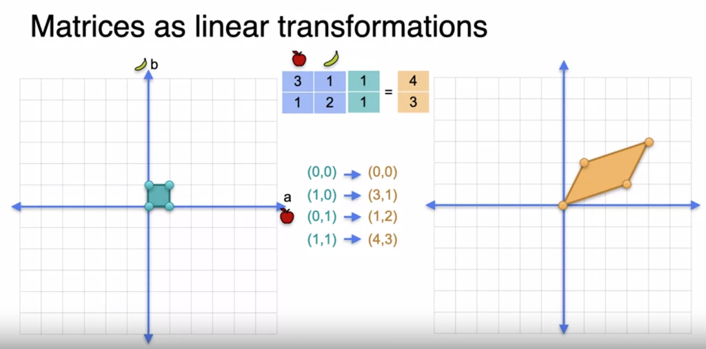

see notes

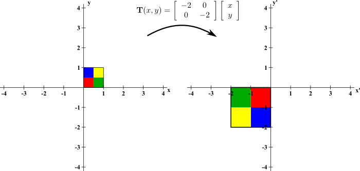

## It wouldn’t be a pseudo-Ed-lecture without some astrophysics, would it?

## Space calculations

- Vectors represent infinitely long lines with no width: an excellent model for a ray of light.
- However, space is curved, so light curves as it moves through space.
- We can model this using a linear map.

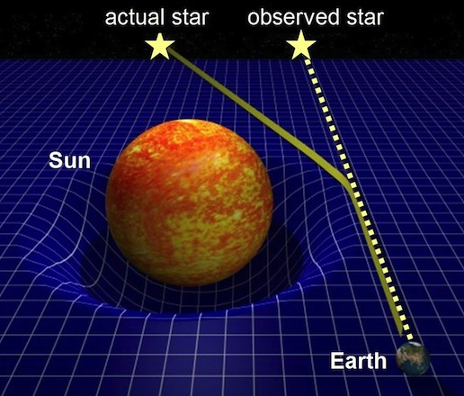

- But wait, I hear you cry, shouldn’t linear maps preserve straight lines?

  Yes… ah nevermind, it was only me who got upset by that part.
- It’s alright, we can still use a *smooth* map to model this transformation, and for our purposes, they work much the same!

## Warping of space

[figure not shown]

- We can think of space as being distorted by a series of equal waves.
- These waves follow a *sinusoidal* pattern.

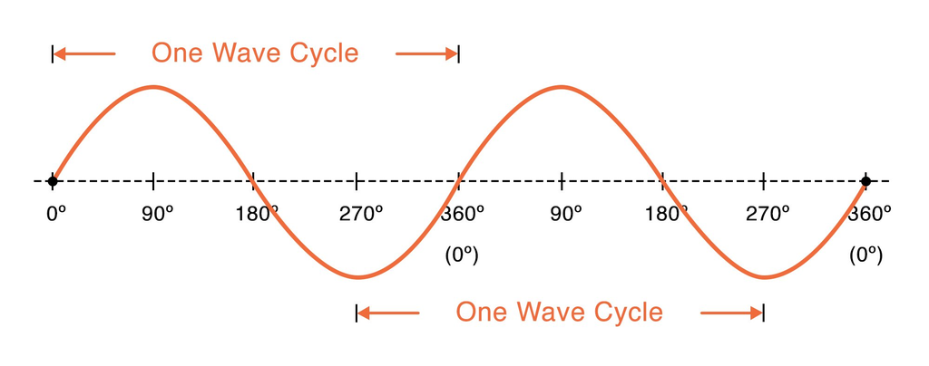

We can transform a straight line into a sin wave by multiplying the \(x\)-value by \(\sin\).

[figure not shown]

## Vectors and information retrieval

The vector space model is one of the simplest information retrieval mechanisms.

Terminology

- **Document**: collection of words
  - We write \(\mathbf{d}_1, \mathbf{d}_2, \ldots\) and refer to them by number \(i\).
- **Query** a word or sequence of words, \(\mathbf{q}\)
  - Our search term
- **Relevance / Similarity**
  - A measure of how closely our query matches a particular document,
  - Defined as the *distance* between \(\mathbf{q}\) and a document \(\mathbf{d}_i\).
  - Formally, we can write \(\Vert \mathbf{q} - \mathbf{d}_i \Vert\)

## Document analysis

In 3d space, we have three axes

Each axis represents a subject

- \(x\)-axis represents Bath Spa,
- \(y\)-axis represents Romans,
- \(z\)-axis represents Computing.

E.g., a document all about Romans, would lie along the \(y\)-axis.

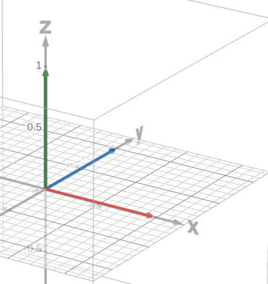

## Document analysis

- Example: a document about Romans and Bath spa,
- Lies somewhere between the \(x\) and \(y\) axis.
- And should not point in the \(z\) direction (for computing) at all.
- E.g., \((2, 1, 0)\)

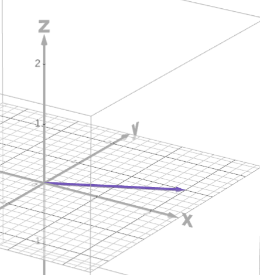

## Document analysis

- Example: a document mentioning Computing and Bath Spa,
- Lies somewhere between the \(x\) and \(z\) axis.
- And should not point in the \(y\) direction (for Romans) at all.
- E.g., \((3, 0, 2)\)

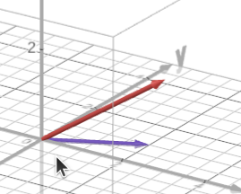

## Search query

- Suppose someone wants to find out about the Computing course at Bath Spa University
- The vector \(\mathbf{q} = (1,0,1)\) is our query.
- We search for the document which is closest to \(\mathbf{q}\)

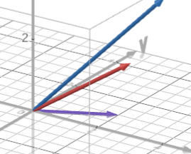

## Closest Calculation

Earlier we worked out the *distance* between two vectors…

- Using Pythagoras’ theorem, extended to 3D.
  - With query \(\mathbf{q} = (q_1, q_2, q_3) = (1, 0, 1)\),
  - For each document \(\mathbf{d}_i = (d_{i1}, d_{i2}, d_{i3})\),
  - Calculate \(\sqrt{(d_{i1} - q_1)^2 + (d_{i2} - q_2)^2 + (d_{i3} - q_3)^2}\).
  - Then choose the document with *minimum distance*
  - Since we only care about relative distances, we can forget about the square root.

## Extending to higher dimensions

- If we had more categories, we could construct a model in a *higher-dimensional vector space*
  - Harder to draw, but just as straightforward to work with (in a computer).
- If we have \(n = 42\) possible document categories, we can represent each document as a \(42\)-dimensional vector:

  \((d_{i1},d_{i2},d_{i3},\ldots,d_{i41},d_{i42})\)
- A query is also a \(42\)-dimensional vector, and we calculate the *squared distance* in the same way:

  \((d_{i1} - q_1)^2 + (d_{i2} - q_2)^2 + (d_{i3} - q_3)^2 + \cdots + (d_{in} - q_n)^2\)

## TF-IDF

## TF-IDF

- *Term Frequency, Inverse Document Frequency*
- Search / information retrieval algorithm
- Gives a measure of *importance of a word to a document*, corrected for the fact that some words are more common than others.
- Simple but powerful model, widely used in, e.g., academic library search.

## Bag of words

- We have \(n\) search terms, and each document will be represented by an \(n\)-vector
- Component \(i\) of the vector represents the weighting of the document to category \(i\).

## For example

We have three documents:

1. Tak does not require that we think of Him, only that we think
2. The first thing Tak did, he wrote himself.
3. Logic is a wonderful thing but doesn’t always beat actual thought.

## Bag Of Words

1. Tak does not require that we think of Him, only that we think

```python
{
    "tak": 1,
    "does": 1,
    "not": 1,
    "require": 1,
    "that": 2,
    "we": 2,
    "think": 2,
    "of": 1,
    "him": 1,
    "only": 1
}

total_words = 13
```

## Term Frequency

\[ \text{Term frequency of } w = \dfrac{\text{occurances of word } w}{\text{total words in document}} \]

For example,

- “Tak” occurs once in \(d_1\),

  \(\mathrm{Tf}(\text{"Tak"}, D_1) = \dfrac{1}{13}\)
- “Think” occurs twice in \(d_1\),

  \(\mathrm{Tf}(\text{"Think"}, D_1) = \dfrac{2}{13}\)

## Inverse document frequency

- Term frequency gives us a measure of how common a word is,
- Inverse document frequency corrects for the distribution of words in our set of documents.
- E.g., in a set of Dracula quotes, the word “blood” is likely to appear often, so it should be less important than less common words, like “paprika”.

## Inverse Document Frequency

\[ \text{inverse document frequency } w = \dfrac{\text{total number of documents}}{\text{number of documents containing } w} \]

1. Tak does not require that we think of Him, only that we think
2. The first thing Tak did, he wrote himself.
3. Logic is a wonderful thing but doesn’t always beat actual thought.

Examples:

- The word “Tak” occurs in two out of three documents

  \(\mathrm{Idf}(\text{"Tak"}, D) = \dfrac{3}{2}\)
- The word “logic” occurs in one out of three documents

## Lab Task: TF-IDF in Python!

Code time…